# Práctica 2

Modelamiento estadístico

Cargar las librerías necesarias

```r
library(AER)       # Econometría aplicada en R (provee conjuntos de datos y herramientas econométricas)
library(tidyverse)   # Colección de paquetes para manipulación y visualización de datos
library(ggplot2)     # Utilizado para crear gráficos
library(dplyr)       # Manipulación de datos (seleccionar, filtrar, mutar, etc.)
library(fixest)
library(psych)# Modelos econométricos (MCO, efectos fijos, etc.)
rm(list=ls())
```

Cargar el conjunto de datos de las escuelas de California

```r
data("CASchools")
?CASchools
```

```
## starting httpd help server ... done
```

Hacemos una descripción de los datos y sacamos el set de variables numéricas

```r
v <- setdiff(names(CASchools), c("district", "school",
                           "county", "grades"))
Hmisc::describe(CASchools)
```

```
## CASchools
##
##  14  Variables      420  Observations
## --------------------------------------------------------------------------------
## district
##        n  missing distinct
##      420        0      420
##
## lowest : 61382 61457 61499 61507 61523, highest: 75051 75085 75119 75135 75440
## --------------------------------------------------------------------------------
## school
##        n  missing distinct
##      420        0      409
##
## lowest : Ackerman Elementary               Adelanto Elementary               Alexander Valley Union Elementary Alisal Union Elementary           Allensworth Elementary
## highest: Woodlake Union Elementary         Woodside Elementary               Woodville Elementary              Wright Elementary                 Yreka Union Elementary
## --------------------------------------------------------------------------------
## county
##        n  missing distinct
##      420        0       45
##
## lowest : Alameda      Butte        Calaveras    Contra Costa El Dorado
## highest: Trinity      Tulare       Tuolumne     Ventura      Yuba
## --------------------------------------------------------------------------------
## grades
##        n  missing distinct
##      420        0        2
##
## Value      KK-06 KK-08
## Frequency     61   359
## Proportion 0.145 0.855
## --------------------------------------------------------------------------------
## students
##        n  missing distinct     Info     Mean  pMedian      Gmd      .05
##      420        0      391        1     2629     1623     3378    139.9
##      .10      .25      .50      .75      .90      .95
##    164.0    379.0    950.5   3008.0   7119.5  10351.1
##
## lowest :    81    92   101   103   104, highest: 19402 20927 21338 25151 27176
## --------------------------------------------------------------------------------
```

[output cut: 63 more lines]

```
##        n  missing distinct     Info     Mean  pMedian      Gmd      .05
##      420        0      322        1      655    655.1    22.86    620.7
##      .10      .25      .50      .75      .90      .95
##    629.4    640.4    655.8    668.7    680.5    688.5
##
## lowest : 604.5 605.5 605.7 608.9 610  , highest: 698.9 699.1 700.9 701.3 704
## --------------------------------------------------------------------------------
## math
##        n  missing distinct     Info     Mean  pMedian      Gmd      .05
##      420        0      324        1    653.3    652.9    21.25    625.4
##      .10      .25      .50      .75      .90      .95
##    629.7    639.4    652.4    665.8    676.8    685.0
##
## lowest : 605.4 609   612.5 613.4 616  , highest: 701.1 701.7 703.6 707.7 709.5
## --------------------------------------------------------------------------------
```

*Pregunta: Cuál es un buen modelo del efecto combinado de las otras variables sobre el rendimiento académico?*

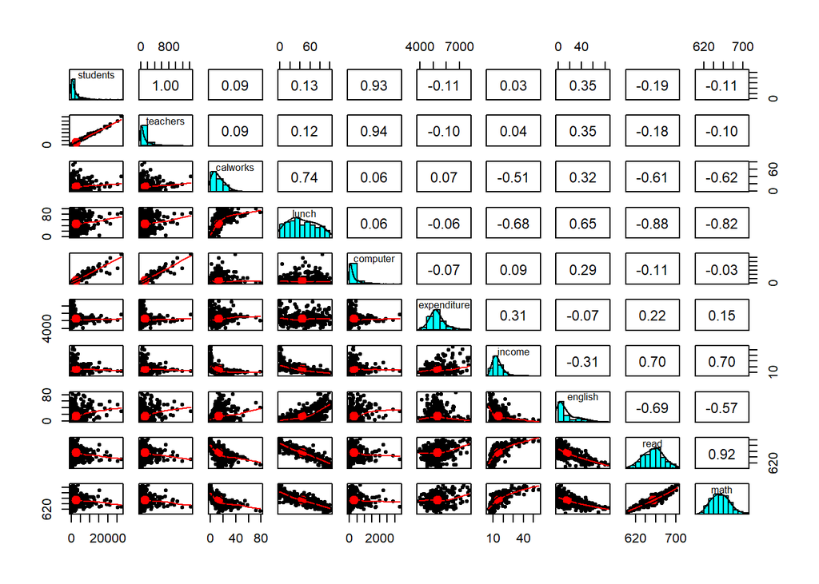

```r
pairs.panels(CASchools[v])
```

`pairs.panel` muestra correlaciones en el triángulo superior, scatterplots en el triángulo inferior y el nombre de la varible junto a su distribución en la diagonal principal.

Al ver esta gráfica notamos la necesidad de hacer ciertas modificaciones sobre los datos:

- El número de profesores no es la variable de interés, sino el número de estudiantes por profesor
- Computadoras tampoco es la variable de interés, sino el número de computadores por estudiante
- Las calificaciones de matemáticas y lectura estan altamente correlacionadas, es preferible reducirlas a una sola variable

# Calcular la relación estudiante-profesor (cantidad de estudiantes por docente en cada distrito)

```r
CASchools$str <- CASchools$students / CASchools$teachers
CASchools$testscr <- (CASchools$read + CASchools$math) / 2
CASchools$compest<-CASchools$computer/CASchools$students
```

Ahora podemos volver a examinar las correlaciones entre los predictores y la variable dependiente

```r
m1corr<-cor(CASchools$testscr,
            CASchools[c("str","lunch", "compest","expenditure", "income", "english")])
t(round(m1corr,2))
```

```
##              [,1]
## str         -0.23
## lunch       -0.87
## compest      0.27
## expenditure  0.19
## income       0.71
## english     -0.64
```

Estimamos un modelo de regresión múltiple

```r
modelo1<-feols(testscr~str + lunch + compest + english, data = CASchools, vcov= "hc1")
etable(modelo1)
```

```
##                             modelo1
## Dependent Var.:             testscr
##
## Constant           694.3*** (6.184)
## str              -0.8354** (0.2790)
## lunch           -0.5446*** (0.0242)
## compest              17.66* (8.194)
## english         -0.1116*** (0.0326)
## _______________ ___________________
## S.E. type       Heteroskedast.-rob.
## Observations                    420
## R2                          0.77765
## Adj. R2                     0.77551
## ---
## Signif. codes: 0 '***' 0.001 '**' 0.01 '*' 0.05 '.' 0.1 ' ' 1
```

**Interpretación** Las variables todas las variables son significativas al $5\%$ de nivel de significancia ($\alpha=0.05$), es decir, que la probabilidad de observar estos coeficientes cuando la hipótesis nula (los coeficientes son realmente 0) es verdadera, es muy improbable.

Cada coeficiente representa el cambio en el rendimiento *promedio* de los estudiantes cuando la variable independiente aumenta en una unidad, **manteniendo las demás constantes**.